# Yangyang_Yu_homework3_ver4

1 Data preparation

1.1 load data

```python
from keras.datasets import cifar10
import numpy as np

# np.random.seed(1337)

(x_train, y_train), (x_test, y_test) = cifar10.load_data()

print("shape of x_train " + str(x_train.shape))
print("shape of y_train " + str(y_train.shape))
print("shape of x_test " + str(x_test.shape))
print("shape of y_test " + str(y_test.shape))
print("number of classes " + str(np.max(y_train) - np.min(y_train) + 1))
```

```
Downloading data from https://www.cs.toronto.edu/~kriz/cifar-10-python.tar.gz
shape of x_train (50000, 32, 32, 3)
shape of y_train (50000, 1)
shape of x_test (10000, 32, 32, 3)
shape of y_test (10000, 1)
number of classes 10
```

1.2. One-hot encode the labels

In the input, a label is a scalar in {0,1,⋯,9} { 0 , 1 , ⋯ , 9 } . One-hot encode transform such a scalar to a 10 10 -dim vector. E.g., a scalar y_train[j]=3 is transformed to the vector y_train_vec[j]=[0, 0, 0, 1, 0, 0, 0, 0, 0, 0].

1. Define a function to_one_hot that transforms an 𝑛×1 n × 1 array to a 𝑛×10 n × 10 matrix.
1. Apply the function to y_train and y_test.

```python
from sklearn.preprocessing import OneHotEncoder


def to_one_hot(labels, num_class=10):
    results = np.zeros((len(labels), num_class))
    for i, label in enumerate(labels):
        results[i,label] = 1
    return results

y_train_vec = to_one_hot(y_train)
y_test_vec = to_one_hot(y_test)
print("y_train_vec[0] ", y_train_vec[0])
print("y_test_vec[0] ", y_test_vec[0])


print("shape of y_train_vec " + str(y_train_vec.shape))
print("shape of y_test_vec " + str(y_test_vec.shape))

print("y_train[0] ", y_train[0])
print("y_train_vec[0] ", y_train_vec[0])
```

```
y_train_vec[0]  [0. 0. 0. 0. 0. 0. 1. 0. 0. 0.]
y_test_vec[0]  [0. 0. 0. 1. 0. 0. 0. 0. 0. 0.]
shape of y_train_vec (50000, 10)
shape of y_test_vec (10000, 10)
y_train[0]  [6]
y_train_vec[0]  [0. 0. 0. 0. 0. 0. 1. 0. 0. 0.]
```

test set size: 10000

train set size: 50000

1.3. Randomly partition the training set to training and validation sets¶

Randomly partition the 50K training samples to 2 sets:

1. a training set containing 40K samples
2. a validation set containing 10K samples

```python
rand_indices = np.random.permutation(50000)
train_indices = rand_indices[0:40000]
valid_indices = rand_indices[40000:50000]

x_val = x_train[valid_indices, :]
y_val = y_train_vec[valid_indices, :]

x_tr = x_train[train_indices, :]
y_tr = y_train_vec[train_indices, :]

print("shape of x_tr " + str(x_tr.shape))
print("shape of y_tr " + str(y_tr.shape))
print("shape of x_val " + str(x_val.shape))
print("shape of y_val " + str(y_val.shape))
```

```
shape of x_tr (40000, 32, 32, 3)
shape of y_tr (40000, 10)
shape of x_val (10000, 32, 32, 3)
shape of y_val (10000, 10)
```

training set size: 40000

validation set size: 10000

1. Build a CNN and tune its hyper-parameters

1) Build a convolutional neural network model

2) Use the validation data to tune the hyper-parameters (e.g., network structure, and optimization algorithm) Do NOT use test data for hyper-parameter tuning!!!

3) Try to achieve a validation accuracy as high as possible.

Remark:

The following CNN is just an example. You are supposed to make substantial improvements such as:

Add more layers.

Use regularizations, e.g., dropout.

Use batch normalization.

```python
# configure GPU and CPU
import tensorflow as tf
import warnings as wa
import keras

wa.filterwarnings("ignore")

config0 = tf.ConfigProto( device_count = {'GPU': 1 , 'CPU': 64} )
session0 = tf.Session(config=config0)
keras.backend.set_session(session0)
```

```python
# Build CNN structure and tune parameters
from keras.models import Sequential, load_model
from keras.layers import Conv2D, MaxPooling2D, Flatten, Dense,BatchNormalization,Activation,Dropout


model0 = Sequential()
# layer 1
model0.add(Conv2D(64, (3, 3), padding='same', input_shape=(32, 32, 3)))
model0.add(Activation('relu'))
model0.add(Conv2D(64, (3, 3), padding='same'))
model0.add(BatchNormalization())
model0.add(Activation('relu'))
model0.add((MaxPooling2D(2, 2)))
# model0.add(Dropout(0.2))

#layer 2
model0.add(Conv2D(128, (3, 3), padding='same'))
model0.add(Activation('relu'))
model0.add(Conv2D(128, (3, 3), padding='same'))
# model0.add(BatchNormalization())
model0.add(Activation('relu'))
model0.add(MaxPooling2D((2, 2)))
# model0.add(Dropout(0.3))

#layer 3
model0.add(Conv2D(256, (3, 3), padding='same'))
model0.add(Activation('relu'))
model0.add(Conv2D(256, (3, 3), padding='same'))
# model0.add(BatchNormalization())
model0.add(Activation('relu'))
model0.add(MaxPooling2D((2, 2), padding='same'))
# model0.add(Dropout(0.3))

# Full Connected Layer
model0.add(Flatten())
model0.add(Dropout(0.5))
model0.add(Dense(512, activation='relu'))
model0.add(Dense(10, activation='softmax'))


model0.summary()
```

[output not shown]

[output cut: 16 more lines]

```
_________________________________________________________________
max_pooling2d_3 (MaxPooling2 (None, 4, 4, 256)         0
_________________________________________________________________
flatten_1 (Flatten)          (None, 4096)              0
_________________________________________________________________
dropout_1 (Dropout)          (None, 4096)              0
_________________________________________________________________
dense_1 (Dense)              (None, 512)               2097664
_________________________________________________________________
dense_2 (Dense)              (None, 10)                5130
=================================================================
Total params: 3,248,458
Trainable params: 3,248,330
Non-trainable params: 128
_________________________________________________________________
```

Below: complie model and plot result

```python
from keras import optimizers

# parameters can be tuned for RMSprop
learning_rate0 = 1e-4
decay0 = 1e-6
#complie model with parameters
model0.compile(loss='categorical_crossentropy',
                optimizer=optimizers.RMSprop(lr=learning_rate0, decay = decay0),
                metrics=['accuracy'])
```

[output not shown]

model without implement data augmentation

```python
# history = model0.fit(x_tr, y_tr, batch_size=32, epochs=50, validation_data=(x_val, y_val))
# model0.save('model_01.h5')
```

Output performance plot without data augmentation

```python
# import matplotlib.pyplot as plt
# accuracy = history.history['acc']
# val_acc = history.history['val_acc']

# epochs = range(len(accuracy))

# plt.plot(epochs, accuracy, 'bo', label="Training Accuracy")
# plt.plot(epochs, val_acc, 'r', label="Validation Accuracy")
# plt.xlabel('Epochs')
# plt.ylabel('Accuracy')
# plt.legend()
# plt.show()
```

model with data augmentation

```python
# implement data augmentation

from keras.preprocessing.image import ImageDataGenerator
# import os
# from datetime import datetime

def train(model, batch, epoch, data_augmentation):


    if data_augmentation:
        aug = ImageDataGenerator(width_shift_range = 0.1,       # 0.125
                                 height_shift_range = 0.1,      # 0.125
                                 rotation_range=15,
                                 horizontal_flip = True)
        aug.fit(x_tr)
        gen = aug.flow(x_tr, y_tr, batch_size=batch)
        h = model.fit_generator(generator=gen,
#                                  steps_per_epoch=50000/batch,
                                 epochs=epoch,
                                 validation_data=(x_val, y_val))
#                                 ,
#                                  callbacks=[es, mc, tb])
    else:
        h = model.fit(x=x_tr,
                      y=y_tr,
                      batch_size=batch,
                      epochs=epoch,
                      validation_data=(x_val, y_val))
#                       ,
#                       callbacks=[es, mc, tb])


    accuracy, val_acc = h.history['acc'], h.history['val_acc']
    return h
```

```python
epoch = 50
batch = 64
data_augmentation = True
model = model0
history0 = train(model, batch, epoch, data_augmentation)
model0.save('model_01_again.h5')
```

```python
h0 = history0
print(h0)
print(type(h0))
```

```
<keras.callbacks.History object at 0x7fc8e28ada58>
<class 'keras.callbacks.History'>
```

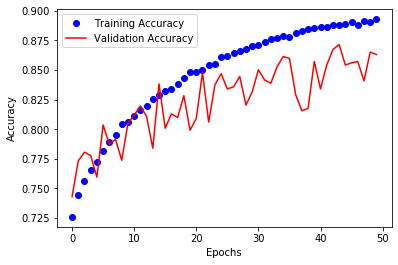

```python
import matplotlib.pyplot as plt


# # accuracy, val_acc = h.history['acc'], h.history['val_acc']
accuracy0 = h0.history['acc']
val_acc0 = h0.history['val_acc']

# accuracy = history0.acc
# val_acc = history0.val_acc

epochs = range(len(accuracy0))

plt.plot(epochs, accuracy0, 'bo', label="Training Accuracy")
plt.plot(epochs, val_acc0, 'r', label="Validation Accuracy")
plt.xlabel('Epochs')
plt.ylabel('Accuracy')
plt.legend()
plt.show()
```

1. Train (again) and evaluate the model¶

To this end, you have found the "best" hyper-parameters.

Now, fix the hyper-parameters and train the network on the entire training set (all the 50K training samples)

Evaluate your model on the test set.

3.1. Train the model on the entire training set

Why? Previously, you used 40K samples for training; you wasted 10K samples for the sake of hyper-parameter tuning.

Now you already know the hyper-parameters, so why not using all the 50K samples for training?

```python
# <Compile your model again (using the same hyper-parameters)>

# parameters can be tuned for RMSprop
learning_rate0 = 1e-4
decay0 = 1e-6
#complie model with parameters
model0.compile(loss='categorical_crossentropy',
                optimizer=optimizers.RMSprop(lr=learning_rate0, decay = decay0),
                metrics=['accuracy'])
```

```python
# <Train your model on the entire training set (50K samples)>
# <Use (x_train, y_train_vec) instead of (x_tr, y_tr)>
# <Do NOT use the validation_data option (because now you do not have validation data)>
#without augmentation
# history2 = model0.fit(x_train, y_train_vec, batch_size=32, epochs=50)


# with augmentation
epoch = 50
batch = 64
data_augmentation = True
aug = ImageDataGenerator(width_shift_range = 0.1,       # 0.125
                         height_shift_range = 0.1,      # 0.125
#                          rotation_range=15,
                         horizontal_flip = True)

aug.fit(x_train)
gen = aug.flow(x_train, y_train_vec, batch_size=batch)
history2 = model0.fit_generator(generator=gen, epochs=epoch)


model0.save('model_02.h5')
```

3.2. Evaluate the model on the test set

Do NOT used the test set until now. Make sure that your model parameters and hyper-parameters are independent of the test set.

```python
loss_and_acc = model0.evaluate(x_test, y_test_vec)
print("loss ", str(loss_and_acc[0]))
print("accuracy ", str(loss_and_acc[1]))
```

```
loss  0.5915325247764588
accuracy  0.8608
```